# Final-Q1

```python
import pandas as pd
import numpy as np
import geopandas as gpd
import matplotlib.pyplot as plt
```

```python
inspections = pd.read_csv("DOHMH_New_York_City_Restaurant_Inspection_Results_20260416.csv")
boroughs = gpd.read_file("Borough_Boundaries_20260416.geojson")
```

```python
print(inspections.columns.tolist())
print(boroughs.columns.tolist())
print(inspections.head())
print(boroughs.head())
```

```
['CAMIS', 'DBA', 'BORO', 'BUILDING', 'STREET', 'ZIPCODE', 'PHONE', 'CUISINE DESCRIPTION', 'INSPECTION DATE', 'ACTION', 'VIOLATION CODE', 'VIOLATION DESCRIPTION', 'CRITICAL FLAG', 'SCORE', 'GRADE', 'GRADE DATE', 'RECORD DATE', 'INSPECTION TYPE', 'Latitude', 'Longitude', 'Community Board', 'Council Di…
[':id', ':version', ':created_at', ':updated_at', 'borocode', 'boroname', 'shape_area', 'shape_leng', 'geometry']
      CAMIS                           DBA       BORO BUILDING  \
0  50183999           FINI BK HEIGHTS LLC   Brooklyn      159
1  50172586  WTC4 BY PONTUS FRITHIOF CORP  Manhattan        4
2  50157005    NILI LOTAN MEATPACKING LLC  Manhattan      183
3  50141491          NEW YORK COMEDY CLUB  Manhattan       85
4  50161368           PETISCO BRAZUCA LLC  Manhattan       20

               STREET  ZIPCODE       PHONE CUISINE DESCRIPTION  \
0   BRIDGE PARK DRIVE  11201.0  8599486217                 NaN
1  WORLD TRADE CENTER  10048.0  9294310800                 NaN
2        DUANE STREET  10013.0  3018202297                 NaN
3    EAST    4 STREET  10003.0  7188409545                 NaN
4   UNION SQUARE WEST  10003.0  6314826603                 NaN
```

[output cut: 43 more lines]

```python
df = inspections[["CAMIS", "DBA", "BORO", "CUISINE DESCRIPTION", "INSPECTION DATE", "SCORE", "GRADE", "VIOLATION CODE", "CRITICAL FLAG",
                "Latitude","Longitude"]].copy()
```

```python
df["INSPECTION DATE"] = pd.to_datetime(df["INSPECTION DATE"], errors="coerce")
df["SCORE"] = pd.to_numeric(df["SCORE"], errors="coerce")

df["BORO"] = df["BORO"].astype(str).str.strip().str.title()
valid_boros = ["Manhattan", "Brooklyn", "Queens", "Bronx", "Staten Island"]
df = df[df["BORO"].isin(valid_boros)].copy()
df = df.dropna(subset=["CAMIS", "INSPECTION DATE"])
```

```python
latest_dates = (
    df.groupby("CAMIS")["INSPECTION DATE"]
    .max()
    .reset_index()
    .rename(columns={"INSPECTION DATE": "LATEST_INSPECTION_DATE"}))

df_latest = df.merge(latest_dates, on="CAMIS", how="left")

df_latest = df_latest[df_latest["INSPECTION DATE"] == df_latest["LATEST_INSPECTION_DATE"]].copy()
```

```python
df_latest["critical_binary"] = np.where(
    df_latest["CRITICAL FLAG"].astype(str).str.strip().str.lower() == "critical", 1, 0)

df_latest["violation_present"] = np.where(df_latest["VIOLATION CODE"].notna(), 1, 0)

df_latest["GRADE"] = df_latest["GRADE"].astype(str).str.strip()

restaurant_level = (
    df_latest.groupby("CAMIS")
    .agg(
        restaurant_name=("DBA", "first"),
        borough=("BORO", "first"),
        cuisine=("CUISINE DESCRIPTION", "first"),
        latest_inspection_date=("INSPECTION DATE", "first"),
        score=("SCORE", "first"),
        grade=("GRADE", "first"),
        violation_count=("violation_present", "sum"),
        critical_violation_count=("critical_binary", "sum"),
        latitude=("Latitude", "first"),
        longitude=("Longitude", "first"))
    .reset_index())

restaurant_level["has_critical_violation"] = np.where(
    restaurant_level["critical_violation_count"] > 0, 1, 0)

print(restaurant_level.head())
```

```
      CAMIS              restaurant_name    borough                   cuisine  \
0  30075445        MORRIS PARK BAKE SHOP      Bronx  Bakery Products/Desserts
1  30191841                D.J. REYNOLDS  Manhattan                     Irish
2  40356018             RIVIERA CATERERS   Brooklyn                  American
3  40356483           WILKEN'S FINE FOOD   Brooklyn                Sandwiches
4  40356731  TASTE THE TROPICS ICE CREAM   Brooklyn           Frozen Desserts

  latest_inspection_date  score grade  violation_count  \
0             2026-02-27    7.0     A                2
1             2025-02-20   10.0     A                2
2             2025-09-17   10.0     A                2
3             2025-01-06   12.0     A                2
4             2025-04-30   12.0     A                4

   critical_violation_count   latitude  longitude  has_critical_violation
0                         1  40.848231 -73.855972                       1
1                         2  40.767326 -73.984310                       1
2                         1  40.579896 -73.982087                       1
3                         2  40.620112 -73.906989                       1
4                         0  40.640795 -73.948488                       0
```

```python
def filter_data(data, cuisine="All", borough="All"):
    temp = data.copy()

    if cuisine != "All":
        temp = temp[temp["cuisine"] == cuisine]

    if borough != "All":
        temp = temp[temp["borough"] == borough]

    return temp
```

```python
filtered_df = filter_data(restaurant_level, cuisine="All", borough="All")

borough_summary = (
    filtered_df.groupby("borough")
    .agg(
        n_restaurants=("CAMIS", "count"),
        avg_score=("score", "mean"),
        median_score=("score", "median"),
        pct_grade_A=("grade", lambda x: (x == "A").mean() * 100),
        pct_grade_B=("grade", lambda x: (x == "B").mean() * 100),
        pct_grade_C=("grade", lambda x: (x == "C").mean() * 100),
        critical_violation_rate=("has_critical_violation", "mean"),
        avg_violation_count=("violation_count", "mean"))
    .reset_index())

borough_summary["critical_violation_rate"] = borough_summary["critical_violation_rate"] * 100

print(borough_summary)
```

```
         borough  n_restaurants  avg_score  median_score  pct_grade_A  \
0          Bronx           2598  13.011412          12.0    68.398768
1       Brooklyn           7858  13.421342          12.0    62.827692
2      Manhattan          12322  13.193159          12.0    62.644051
3         Queens           6948  14.382896          12.0    61.067933
4  Staten Island           1090  14.540020          12.0    58.165138

   pct_grade_B  pct_grade_C  critical_violation_rate  avg_violation_count
0     4.926867     0.423403                77.174750             2.545804
1     4.403156     0.419954                71.583100             2.497582
2     3.619542     0.340854                71.222204             2.461532
3     5.670697     0.388601                77.086931             2.772596
4     3.669725     0.733945                77.981651             2.610092
```

```python
boroughs["boroname"] = boroughs["boroname"].astype(str).str.strip().str.title()

map_df = boroughs.merge(
    borough_summary,
    left_on="boroname",
    right_on="borough",
    how="left")

print(map_df[["boroname", "pct_grade_A", "avg_score", "critical_violation_rate"]])
```

```
        boroname  pct_grade_A  avg_score  critical_violation_rate
0  Staten Island    58.165138  14.540020                77.981651
1      Manhattan    62.644051  13.193159                71.222204
2          Bronx    68.398768  13.011412                77.174750
3       Brooklyn    62.827692  13.421342                71.583100
4         Queens    61.067933  14.382896                77.086931
```

To compare differences across boroughs consistently, we aggregated the data to the restaurant level and kept only the latest inspection record for each restaurant. This ensures each restaurant is included only once in the analysis. We define the critical Violation rate as the percentage of restaurants with at least one recorded critical violation in the latest inspection record. We also consider the average inspection score as another important indicator, with higher scores indicating worse inspection outcomes.

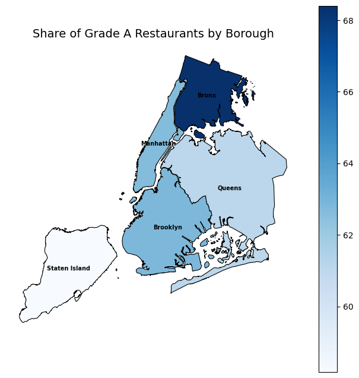

```python
fig, ax = plt.subplots(figsize=(8, 8))

map_df.plot(
    column="pct_grade_A",
    cmap="Blues",
    linewidth=0.8,
    edgecolor="black",
    legend=True,
    ax=ax,
    missing_kwds={"color": "lightgrey", "label": "No data"})

for idx, row in map_df.iterrows():
    x = row.geometry.centroid.x
    y = row.geometry.centroid.y
    ax.text(
        x, y,
        row["boroname"],
        fontsize=7,
        ha="center",
        va="center",
        color="black",
        fontweight="bold")

ax.set_title("Share of Grade A Restaurants by Borough", fontsize=14)
ax.axis("off")

plt.show()
```

The share of Grade A restaurants isn't evenly distributed across the boroughs, as depicted in the map. It is the highest in the Bronx and the lowest in Staten Island. Brooklyn and Manhattan are similar and range in the middle, while Queens seems a little lower than the two.

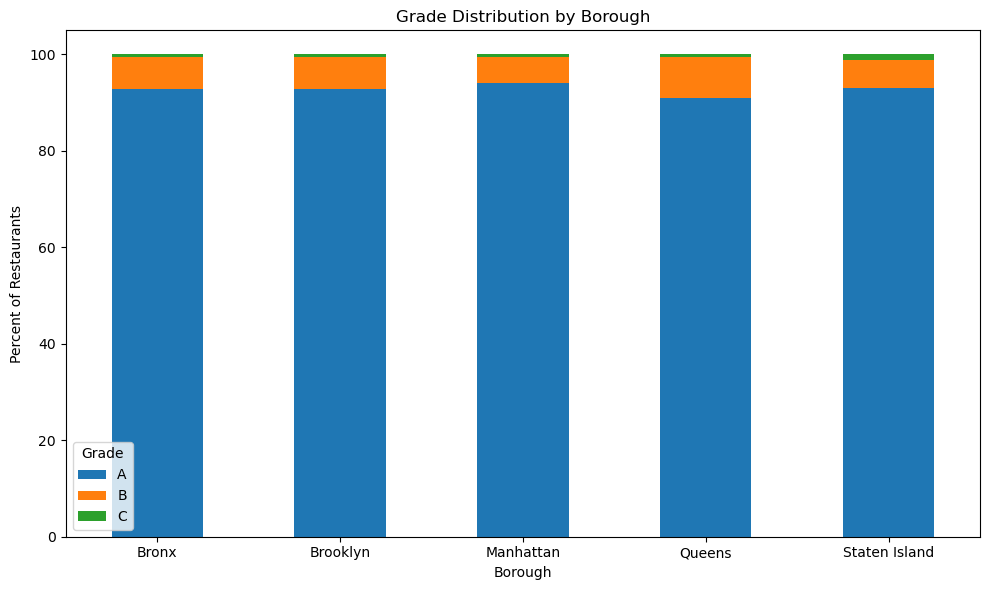

```python
grade_df = filtered_df[filtered_df["grade"].isin(["A", "B", "C"])].copy()

grade_dist = (
    grade_df.groupby(["borough", "grade"])
    .size()
    .reset_index(name="count"))

grade_dist["pct"] = (grade_dist["count"] / grade_dist.groupby("borough")["count"].transform("sum")) * 100

grade_pivot = grade_dist.pivot(index="borough", columns="grade", values="pct").fillna(0)
grade_pivot = grade_pivot.reindex(columns=["A", "B", "C"], fill_value=0)

grade_pivot.plot(
    kind="bar",
    stacked=True,
    figsize=(10, 6))

plt.title("Grade Distribution by Borough")
plt.xlabel("Borough")
plt.ylabel("Percent of Restaurants")
plt.xticks(rotation=0)
plt.legend(title="Grade")
plt.tight_layout()
plt.show()
```

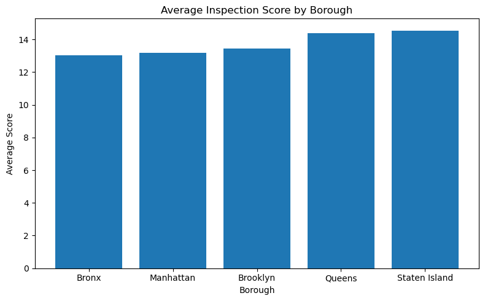

```python
score_plot = borough_summary.sort_values("avg_score")

plt.figure(figsize=(8, 5))
plt.bar(score_plot["borough"], score_plot["avg_score"])
plt.title("Average Inspection Score by Borough")
plt.xlabel("Borough")
plt.ylabel("Average Score")
plt.xticks(rotation=0)
plt.tight_layout()
plt.show()
```

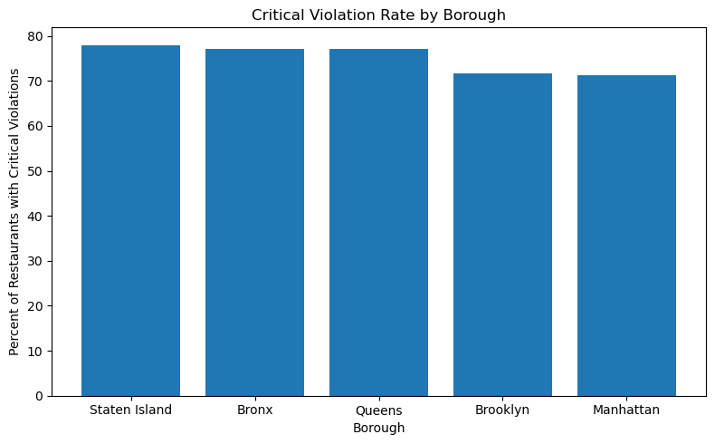

```python
critical_plot = borough_summary.sort_values("critical_violation_rate", ascending=False)

plt.figure(figsize=(8, 5))
plt.bar(critical_plot["borough"], critical_plot["critical_violation_rate"])
plt.title("Critical Violation Rate by Borough")
plt.xlabel("Borough")
plt.ylabel("Percent of Restaurants with Critical Violations")
plt.xticks(rotation=0)
plt.tight_layout()
plt.show()
```

Queens also shows a high average inspection score, and the Bronx has the lowest average inspection score, but the Bronx still shows relatively high critical violation rates. Overall, the borough rankings differ slightly across the metrics used, but Staten Island remains at one of the weaker ends of its distribution.

Interactive charts

```python
import altair as alt

interactive_df = borough_summary[
    ["borough", "avg_score", "pct_grade_A", "critical_violation_rate", "n_restaurants"]].copy()

plot_df = interactive_df.melt(
    id_vars=["borough", "n_restaurants"],
    value_vars=["avg_score", "pct_grade_A", "critical_violation_rate"],
    var_name="metric",
    value_name="value")

label_map = {
    "avg_score": "Average Inspection Score",
    "pct_grade_A": "Grade A Share (%)",
    "critical_violation_rate": "Critical Violation Rate (%)"}
plot_df["metric_label"] = plot_df["metric"].map(label_map)

metric_dropdown = alt.param(
    name="Metric",
    bind=alt.binding_select(
        options=[
            "Average Inspection Score",
            "Grade A Share (%)",
            "Critical Violation Rate (%)"],
        name="Choose metric: "),
    value="Average Inspection Score")

bars = (
    alt.Chart(plot_df)
    .add_params(metric_dropdown)
    .transform_filter(alt.datum.metric_label == metric_dropdown)
    .mark_bar(cornerRadiusTopRight=4, cornerRadiusBottomRight=4)
    .encode(
        y=alt.Y(
            "borough:N",
            sort="-x",
            title="Borough"),
        x=alt.X(
            "value:Q",
            title="Value"),
        tooltip=[
            alt.Tooltip("borough:N", title="Borough"),
            alt.Tooltip("metric_label:N", title="Metric"),
            alt.Tooltip("value:Q", title="Value", format=".2f"),
            alt.Tooltip("n_restaurants:Q", title="Number of Restaurants")])
    .properties(
        width=650,
        height=280,
        title="Comparison of Restaurant Inspection Metrics Across NYC Boroughs"))

labels = (
    alt.Chart(plot_df)
    .add_params(metric_dropdown)
    .transform_filter(alt.datum.metric_label == metric_dropdown)
    .mark_text(
        align="left",
        baseline="middle",
        dx=4)
    .encode(
        y=alt.Y("borough:N", sort="-x"),
        x=alt.X("value:Q"),
        text=alt.Text("value:Q", format=".2f")))

interactive_chart = bars + labels
interactive_chart
```

[interactive chart not shown]

```python
import altair as alt
import json

borough_map = boroughs.copy()

borough_map = borough_map.merge(
    borough_summary[["borough", "avg_score", "pct_grade_A", "critical_violation_rate", "n_restaurants"]],
    left_on="boroname",
    right_on="borough",
    how="left")

borough_map = borough_map[["boroname", "geometry", "avg_score", "pct_grade_A", "critical_violation_rate", "n_restaurants"]].copy()

borough_map = borough_map.dropna(subset=["avg_score"])

borough_json = json.loads(borough_map.to_json())

interactive_map = (
    alt.Chart(alt.Data(values=borough_json["features"]))
    .mark_geoshape(stroke="white", strokeWidth=1)
    .encode(
        color=alt.Color(
            "properties.avg_score:Q",
            title="Average Score"),
        tooltip=[
            alt.Tooltip("properties.boroname:N", title="Borough"),
            alt.Tooltip("properties.avg_score:Q", title="Average Score", format=".2f"),
            alt.Tooltip("properties.pct_grade_A:Q", title="Grade A Share (%)", format=".2f"),
            alt.Tooltip("properties.critical_violation_rate:Q", title="Critical Violation Rate (%)", format=".2f"),
            alt.Tooltip("properties.n_restaurants:Q", title="Number of Restaurants")])
    .properties(
        width=500,
        height=500,
        title="Restaurant Inspection Outcomes Across NYC Boroughs"))

interactive_map
```

[interactive chart not shown]